# AH Statistics Prelim Topic Revision - Web Version

## 9 Distribution of the Sample Mean

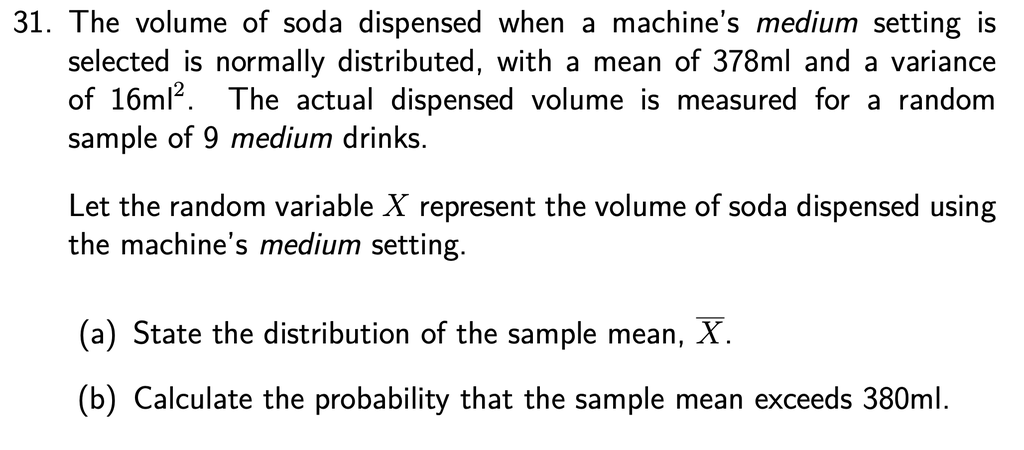

The $z$ transformation for a **sample mean** involves $n$.

It may now be familiar as the *test statistic* for a one-sample $z$ test:

$z=\dfrac{\bar{x}-\mu}{\cfrac{\sigma}{\sqrt{n}}}$

1. $\overline{X}\sim \text{N}\left(378,\frac{\text{16}}{\text{9}}\right)$
2. $\text{P}(\overline{X}> 380)=\text{0.0668}$

[figure not shown]

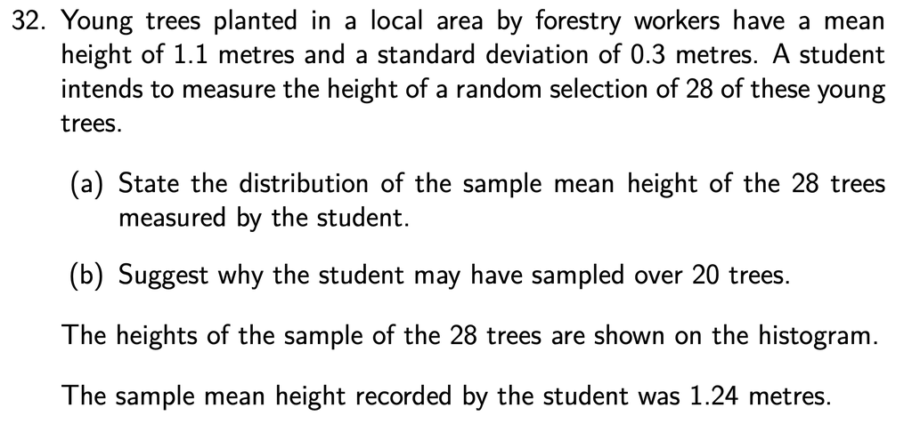

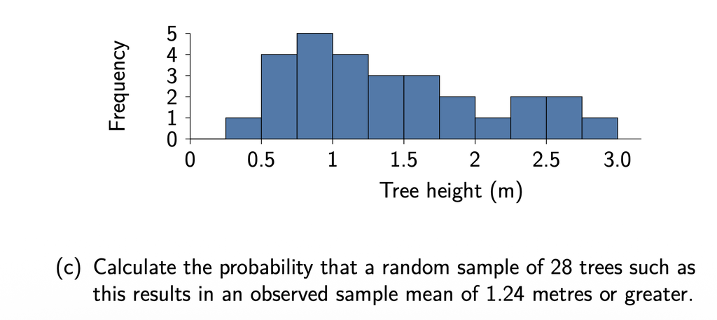

Learn what the Central Limit Theorem actually means, rather than just "sample size greater than 20 so CLT something something..."

You'll find it written clearly in your notes.

1. $\overline{X}\approx \text{N}\left(1.1,\frac{\text{0.3}^\text{2}}{\text{28}}\right)$
2. Since the underlying distribution is not known, a sample size greater than 20 helps by allowing the Central Limit Theorem to be invoked, meaning the distribution of the sample mean is approximately distributed anyway.
3. $\text{P}(\overline{X}> 1.24)=\text{0.0068}$

[figure not shown]

## 10 Hypothesis Testing I

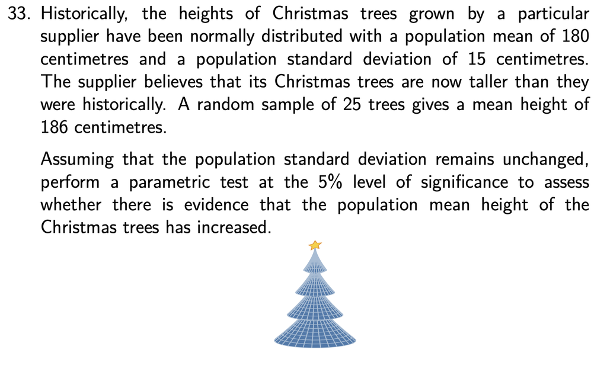

Since the **population standard deviation is known**, this is a $z$ test.

Pay attention to each of the 6 marks available here - good habits with hypothesis testing will serve you well for the remainder of the course!

Since $\text{2.00}>\text{1.64}$, reject $\text{H}_{\text{0}}$ at the 5% level of significance. There is sufficient evidence to suggest that the population mean height of the Christmas trees has increased from 180 centimetres.

[figure not shown]

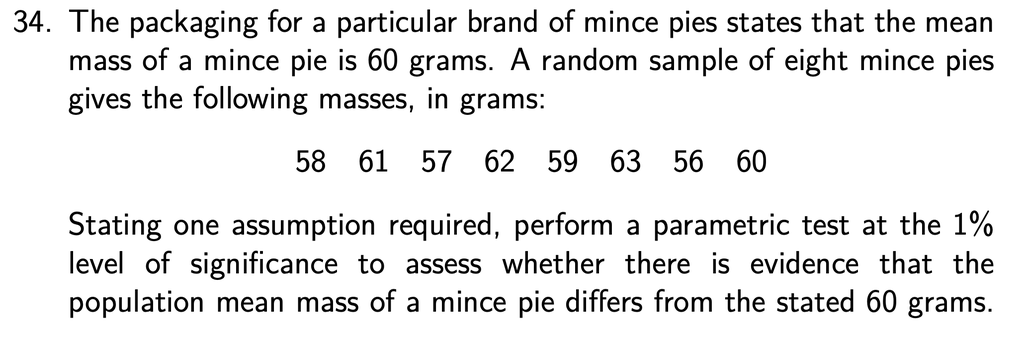

Since the **population standard deviation is not known**, and the *sample standard deviation*, $s$, will be used instead, this is a $t$ test.

Make sure you refer to $t$ critical values and not $z$ values.

Assume that the mass of a mince pie is normally distributed. Since $-\text{0.577}>-\text{3.499}$, do not reject $\text{H}_{\text{0}}$ at the 1% level of significance. There is insufficient evidence to suggest that the population mean mass of a mince pie differs from the stated 60 grams.

[figure not shown]

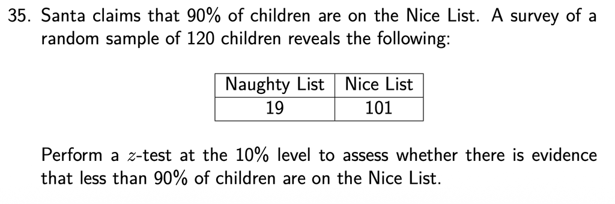

Since we are looking at a **proportion** this is a $z$ test for proportion.

Practising choosing and performing hypothesis testing carefully puts you on Santa's Nice List.

$np=\text{120}\times\text{0.9}=\text{108}>5$ and $nq=\text{120}\times\text{0.1}=\text{12}>5$, so a normal approximation is appropriate. Since $-\text{2.13}<-\text{1.28}$, reject $\text{H}_{\text{0}}$ at the 10% level of significance. There is sufficient evidence to suggest that less than 90% of children are on the Nice List.

[figure not shown]

## 11 Confidence Intervals

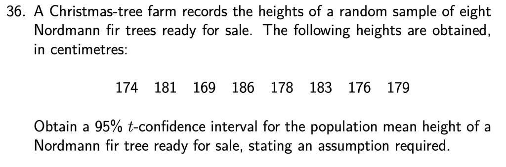

[figure not shown]

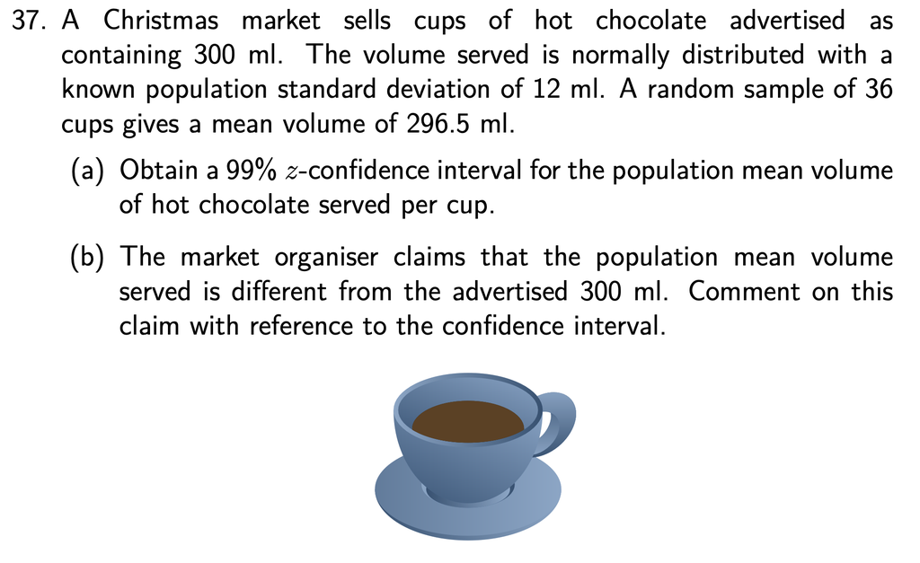

[figure not shown]

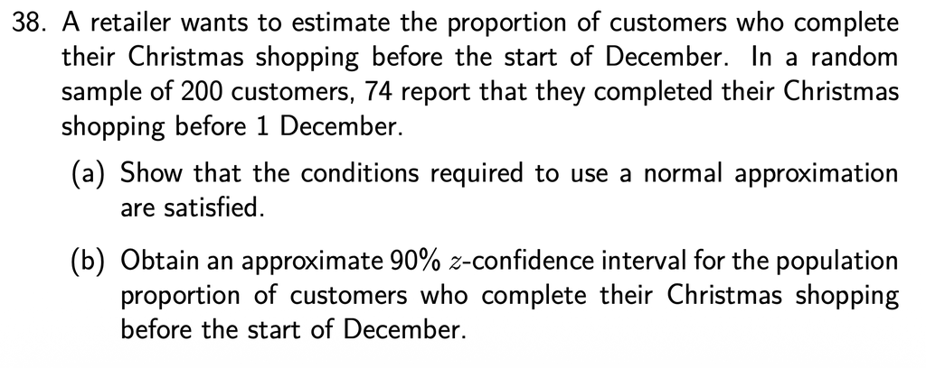

[figure not shown]

## 12 Chi-Squared Goodness-of-fit Test

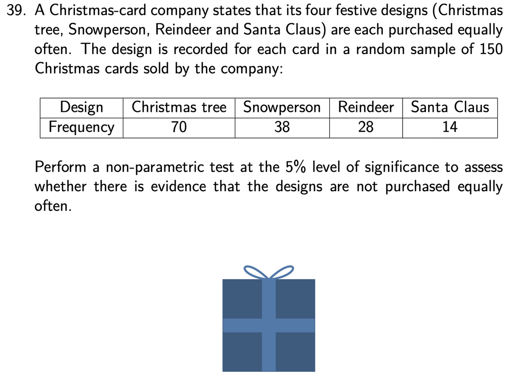

[figure not shown]

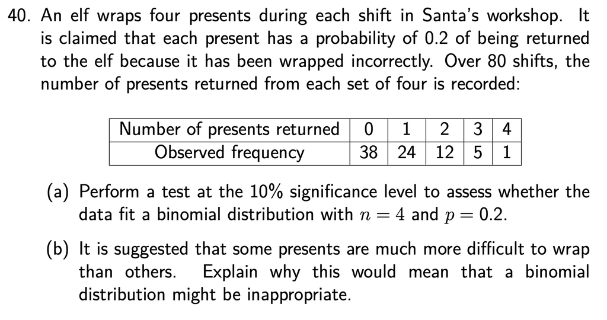

[figure not shown]

## 13 Control Charts

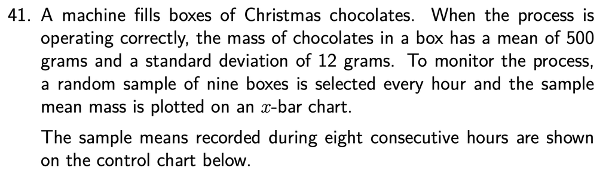

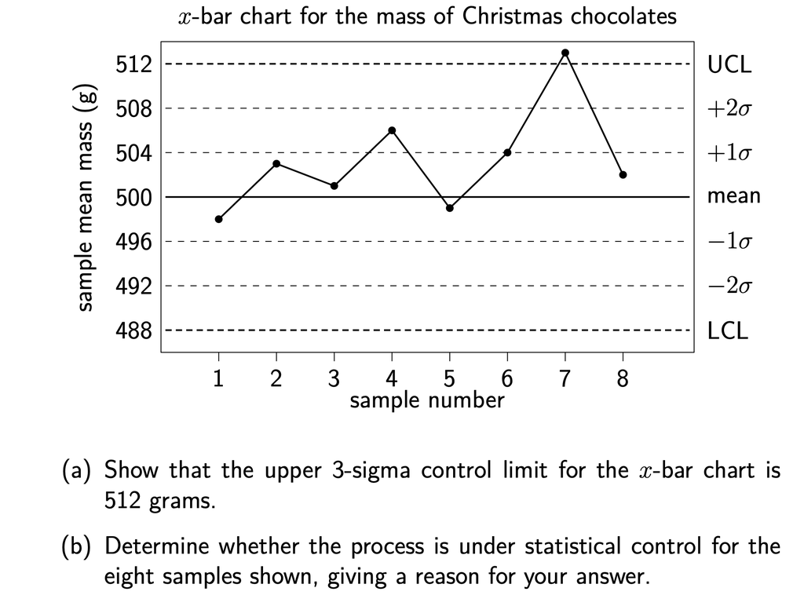

[figure not shown]

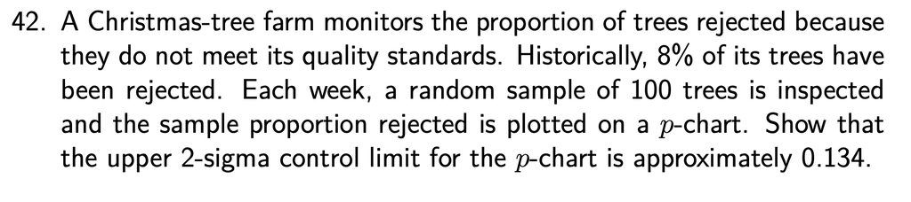

[figure not shown]